# vivekvajipey_A8

[interactive chart not shown]

[interactive chart not shown]

[interactive chart not shown]

[interactive chart not shown]

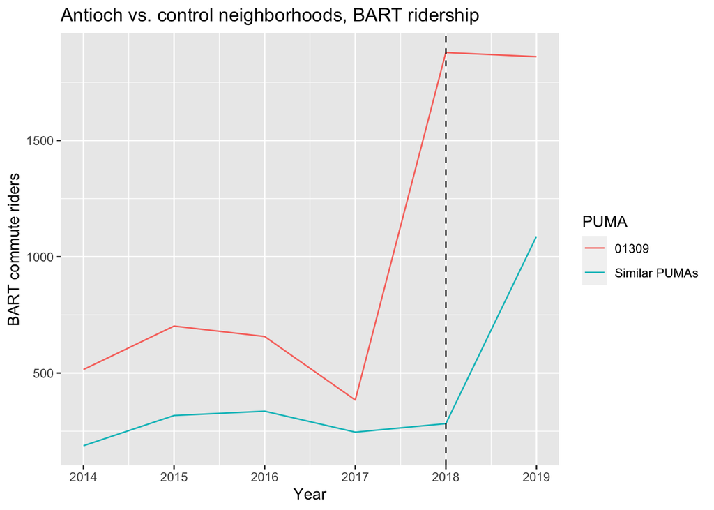

Based on the results of difference-in-differences analysis, the DiD effect size of the Antioch BART station is 891.12, which indicates that the station had an estimated impact of approximately 890 new BART commuters. This result appears to be significant, considering that the p-value of 0.0006344 is less than 5%.

The DiD analysis took into account the pre-treatment difference between the control and treatment PUMAs, which has an estimated value of 292.78, and the change in the control PUMAs from before and after the treatment, which has an estimated value of 413.38. Overall, the DiD effect size of 891.12 quantifies the effect of the treatment accounting for the baseline differences.

Many of the main assumptions of these results and this model are similar to the textbook example, such as the exclusive tracking of commute ridership rather than total ridership and the use of the “Subway or elevated car” response from the ACS questionnaire. One key difference is the timing of the opening, with the Antioch BART station being opened in May 2018 and the Warm Springs/South Fremont BART station being opened in March 2017. Since we used the 2014 to 2019 PUMS data, this provided only two years of post-treatment data for the Antioch station while there were three years of post-treatment data for the Warm Springs/South Fremont station. Additionally, the month of opening (May vs. March) and its relation to the timing of PUMS response sampling further contributes to the differences between these cases. As is the case with any DiD, there is always potential for other factors to have been controlled for.